# TMDB Prediction - R-Collab

Mike and Goutham

September 22, 2019

# TMDB Predict - R Collab

## 1. Data loading and cleaning

```r
library(tidyverse)
library(jsonlite)
library(DT)
```

```r
data <- read_csv("train.csv")
print(data)
```

```
## # A tibble: 3,000 x 23
##       id belongs_to_coll~ budget genres homepage imdb_id original_langua~
##    <dbl> <chr>             <dbl> <chr>  <chr>    <chr>   <chr>
##  1     1 [{'id': 313576,~ 1.40e7 [{'id~ <NA>     tt2637~ en
##  2     2 [{'id': 107674,~ 4.00e7 [{'id~ <NA>     tt0368~ en
##  3     3 <NA>             3.30e6 [{'id~ http://~ tt2582~ en
##  4     4 <NA>             1.20e6 [{'id~ http://~ tt1821~ hi
##  5     5 <NA>             0.     [{'id~ <NA>     tt1380~ ko
##  6     6 <NA>             8.00e6 [{'id~ <NA>     tt0093~ en
##  7     7 <NA>             1.40e7 [{'id~ http://~ tt0431~ en
##  8     8 <NA>             0.     [{'id~ <NA>     tt0391~ en
##  9     9 [{'id': 256377,~ 0.     [{'id~ <NA>     tt0117~ en
## 10    10 <NA>             6.00e6 [{'id~ <NA>     tt0310~ en
## # ... with 2,990 more rows, and 16 more variables: original_title <chr>,
## #   overview <chr>, popularity <dbl>, poster_path <chr>,
## #   production_companies <chr>, production_countries <chr>,
## #   release_date <chr>, runtime <dbl>, spoken_languages <chr>,
## #   status <chr>, tagline <chr>, title <chr>, Keywords <chr>, cast <chr>,
## #   crew <chr>, revenue <dbl>
```

We load our initial data as a tibble, and start inspecting it. As a tibble, we can safely load it and it just gives us the first ten rows with color-coded information on column types.

In looking at the data, some of the columns are poorly-formed JSON data. They have (for example), single quotation marks where JSON requires double. Changing all the singles to doubles would mess up all of the single quotation marks already present in the data (possessives, french connectives, etc.) and so brute force gsub() and manually editing the data in a spreadsheet were going to end up being too time intensive.

Luckly, Georgi Petkov posted some code on the Kaggle website (https://www.kaggle.com/georgipetkov/json-columns-to-data-frame) that parses this particular data set rather well. It strips all of the punctuations, loads the data into matrices, and then converts them to tibbles.

```r
cast_list <- list()

for (i in seq_along(data$cast)) {
  cast_list[[i]] <- data$cast[[i]] %>%
    str_extract_all('(?<=\\{).*?(?=\\})') %>%  #extract everything between {}
    str_split("(?<=[:digit:]|[:punct:]), ", n=Inf,simplify = TRUE) %>%       #split on ","
    str_extract_all('(?<=\\:[:space:]).*') %>% #get the part after the semicolon
    str_replace_all("'|\"","") %>% #clean the unwanted punctuation
    matrix( ncol = 8,  byrow = TRUE,dimnames=list(c(),
                                                  c("cast_id","character","credit_id","gender","id", "name","order","profile_path"))) %>% #convert to matrix
    as_tibble(stringsAsFactors = FALSE)#convert the matrix to tibble
}

# Name the list
names(cast_list) <- c(1:3000) #name the list with the sequential number of the list element

# Create df with a column that identifies each movie
cast_df <- bind_rows(cast_list, .id = 'movie_id')#create single df with a column that identifies the movies


cast_df  %>%
  head(10) %>%
  DT::datatable()
```

|  | movie_id | cast_id | character | credit_id | gender | id | name | order | profile_path |
| --- | --- | --- | --- | --- | --- | --- | --- | --- | --- |
| 1 | 1 | 4 | Lou | 52fe4ee7c3a36847f82afae7 | 2 | 52997 | Rob Corddry | 0 | /k2zJL0V1nEZuFT08xUdOd3ucfXz.jpg |
| 2 | 1 | 5 | Nick | 52fe4ee7c3a36847f82afaeb | 2 | 64342 | Craig Robinson | 1 | /tVaRMkJXOEVhYxtnnFuhqW0Rjzz.jpg |
| 3 | 1 | 6 | Jacob | 52fe4ee7c3a36847f82afaef | 2 | 54729 | Clark Duke | 2 | /oNzK0umwm5Wn0wyEbOy6TVJCSBn.jpg |
| 4 | 1 | 7 | Adam Jr. | 52fe4ee7c3a36847f82afaf3 | 2 | 36801 | Adam Scott | 3 | /5gb65xz8bzd42yjMAl4zwo4cvKw.jpg |
| 5 | 1 | 8 | Hot Tub Repairman | 52fe4ee7c3a36847f82afaf7 | 2 | 54812 | Chevy Chase | 4 | /svjpyYtPwtjvRxX9IZnOmOkhDOt.jpg |
| 6 | 1 | 9 | Jill | 52fe4ee7c3a36847f82afafb | 1 | 94098 | Gillian Jacobs | 5 | /rBnhe5vhNPnhRUdtYahBWx90fJM.jpg |
| 7 | 1 | 10 | Sophie | 52fe4ee7c3a36847f82afaff | 1 | 1159009 | Bianca Haase | 6 | /4x3nbtD8q8phAJPmoGWXPvz0iM.jpg |
| 8 | 1 | 11 | Kelly | 5524ec51c3a3687df3000dbb | 1 | 86624 | Collette Wolfe | 7 | /aSD4h5379b2eEw3bLou9ByLimmq.jpg |
| 9 | 1 | 13 | Brad | 5524ec8ec3a3687ded000d72 | 2 | 466505 | Kumail Nanjiani | 9 | /x4nAztHY72SVciRfxEsbhIVTsIu.jpg |
| 10 | 1 | 14 | Courtney | 5524ec9bc3a3687df8000d13 | 1 | 70776 | Kellee Stewart | 10 | /w3xmsEPmJc1Cf0dQ4aIn8YmlHbk.jpg |

```r
genres_list <- list()
for (i in seq_along(data$genres)) {
  genres_list[[i]] <- data$genres[[i]] %>%
    str_extract_all('(?<=\\{).*?(?=\\})') %>%
    str_split("(?<=[:digit:]|[:punct:]), ",n=Inf,simplify = TRUE) %>%
    str_extract_all('(?<=\\:[:space:]).*') %>%
    str_replace_all("[:punct:]","") %>%
    matrix( ncol = 2,  byrow = TRUE,dimnames=list(c(),
                                                  c("id","name"))) %>%
    as_tibble(stringsAsFactors = FALSE)
}

names(genres_list) <- c(1:3000)

genres_df <- bind_rows(genres_list, .id = 'movie_id')

genres_df %>%
  head(10) %>%
  DT::datatable()
```

|  | movie_id | id | name |
| --- | --- | --- | --- |
| 1 | 1 | 35 | Comedy |
| 2 | 2 | 35 | Comedy |
| 3 | 2 | 18 | Drama |
| 4 | 2 | 10751 | Family |
| 5 | 2 | 10749 | Romance |
| 6 | 3 | 18 | Drama |
| 7 | 4 | 53 | Thriller |
| 8 | 4 | 18 | Drama |
| 9 | 5 | 28 | Action |
| 10 | 5 | 53 | Thriller |

```r
# dim(genres_df)
```

```r
production_companies_list <- list()
for (i in seq_along(data$production_companies)) {
  production_companies_list[[i]] <- data$production_companies[[i]] %>%
    str_extract_all('(?<=\\{).*?(?=\\})') %>%
    str_split("(?<=[:digit:]|[:punct:]), ",n=Inf,simplify = TRUE) %>%
    str_extract_all('(?<=\\:[:space:]).*') %>%
    str_replace_all("[:punct:]","") %>%
    matrix( ncol = 2,  byrow = TRUE,dimnames=list(c(),
                                                  c("name","id"))) %>%
    as_tibble(stringsAsFactors = FALSE)
}

names(production_companies_list) <- c(1:3000)

production_companies_df <- bind_rows(production_companies_list, .id = 'movie_id')


production_companies_df %>%
  head(20) %>%
  DT::datatable()
```

|  | movie_id | name | id |
| --- | --- | --- | --- |
| 1 | 1 | Paramount Pictures | 4 |
| 2 | 1 | United Artists | 60 |
| 3 | 1 | MetroGoldwynMayer MGM | 8411 |
| 4 | 2 | Walt Disney Pictures | 2 |
| 5 | 3 | Bold Films | 2266 |
| 6 | 3 | Blumhouse Productions | 3172 |
| 7 | 3 | Right of Way Films | 32157 |
| 8 | 4 |  |  |
| 9 | 5 |  |  |
| 10 | 6 |  |  |

[output cut: 10 more lines]

```r
crew_list <- list()

for (i in seq_along(data$crew)) {
  crew_list[[i]] <- data$crew[[i]] %>%
    str_extract_all('(?<=\\{).*?(?=\\})') %>%
    str_split("(?<=[:digit:]|[:punct:]), ",n=Inf,simplify = TRUE) %>%
    str_extract_all('(?<=\\:[:space:]).*') %>%
    str_replace_all("[:punct:]","") %>%
    matrix( ncol = 7,  byrow = TRUE,dimnames=list(c(),
   c("credit_id","department","gender","id","job","name","profile_path"))) %>%
    as_tibble(stringsAsFactors = FALSE)
}

names(crew_list) <- c(1:3000)

crew_df <- bind_rows(crew_list, .id = 'movie_id')

crew_df%>%
  head(10) %>%
  DT::datatable()
```

|  | movie_id | credit_id | department | gender | id | job | name | profile_path |
| --- | --- | --- | --- | --- | --- | --- | --- | --- |
| 1 | 1 | 59ac067c92514107af02c8c8 | Directing | 0 | 1449071 | First Assistant Director | Kelly Cantley | None |
| 2 | 1 | 52fe4ee7c3a36847f82afad7 | Directing | 2 | 3227 | Director | Steve Pink | myHOgo8mQSCiCAZNGMRdHVr03jrjpg |
| 3 | 1 | 5524ed25c3a3687ded000d88 | Writing | 2 | 347335 | Writer | Josh Heald | pwXJIenrDMrG7t3zNfLvr8w1RGUjpg |
| 4 | 1 | 5524ed2d925141720c001128 | Writing | 2 | 347335 | Characters | Josh Heald | pwXJIenrDMrG7t3zNfLvr8w1RGUjpg |
| 5 | 1 | 5524ed3d92514166c1004a5d | Production | 2 | 57822 | Producer | Andrew Panay | None |
| 6 | 1 | 5524ed4bc3a3687df3000dd2 | Production | 0 | 1451395 | Associate Producer | Adam Blum | None |
| 7 | 1 | 5524ed5a925141720c00112c | Production | 2 | 52997 | Executive Producer | Rob Corddry | k2zJL0V1nEZuFT08xUdOd3ucfXzjpg |
| 8 | 1 | 5524ed85c3a3687e0e000f56 | Production | 0 | 62807 | Executive Producer | Ben Ormand | None |
| 9 | 1 | 5524ed9fc3a3687e0e000f59 | Sound | 2 | 23486 | Original Music Composer | Christophe Beck | 2fnJUmCk6IEpVIptpYaUk31epHxjpg |
| 10 | 1 | 5524eda6c3a3687e03000d28 | Camera | 2 | 6117 | Director of Photography | Declan Quinn | None |

## 2. Exploratory Data Analysis

Let’s see what we have in the ‘budget’ column.

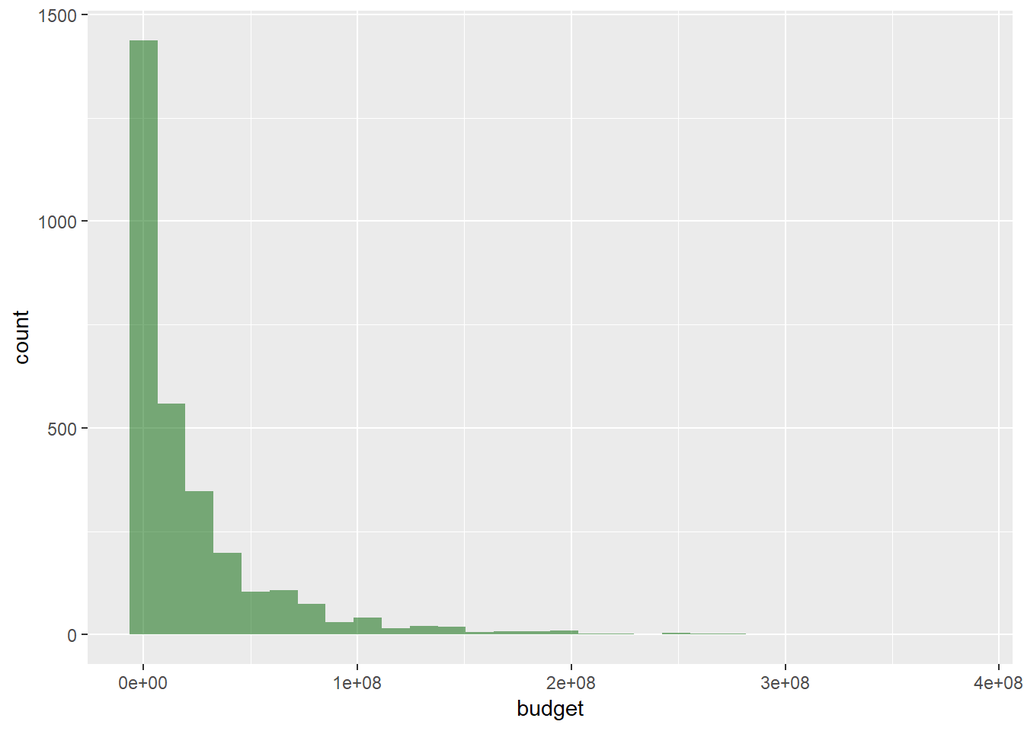

```r
plot <- ggplot(data = data) +
  geom_histogram(aes(x = budget), fill = "dark green", alpha = 0.5)
print(plot)
```

Let’s zoom on the left side of this graph.

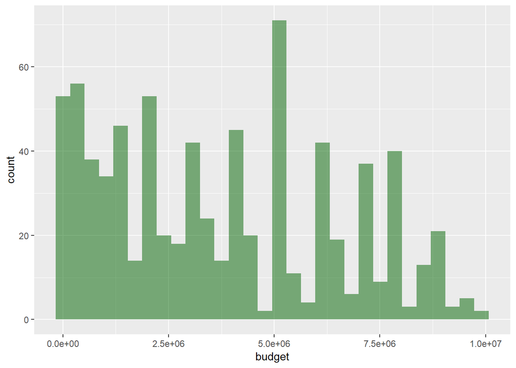

```r
cheap.movies <- subset(data, budget > 0 & budget < 10000000)

plot <- ggplot(data = cheap.movies) +
  geom_histogram(aes(x = budget), fill = "dark green", alpha = 0.5)
print(plot)
```

Looks like the movies between 0 and 10 million are fairly even distributed, getting more sparse as they approach 10 million.

We can guess that there’s some sort of relationship between budget and revenue, but lets visualize and see.

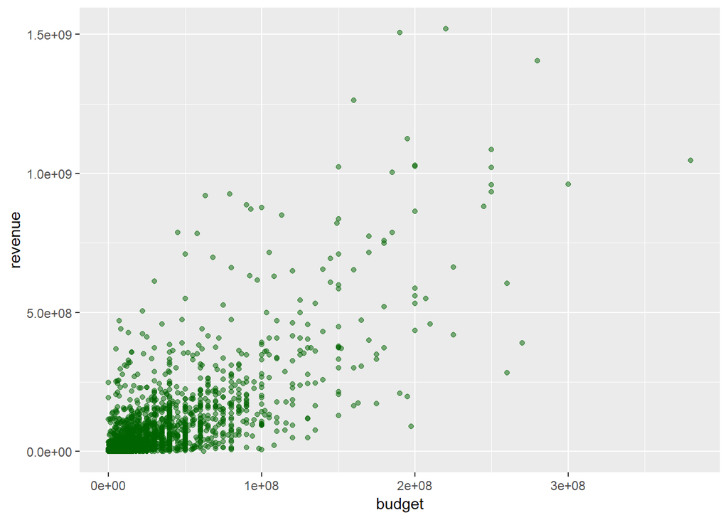

```r
nonzero.movies <- subset(data, budget > 0)

plot <- ggplot(data = nonzero.movies) +
  geom_point(aes(x = budget, y = revenue), color = "dark green", alpha = 0.5)
print(plot)
```

Our guess would appear to be roughly accurate.

Let’s add a linear regression line.

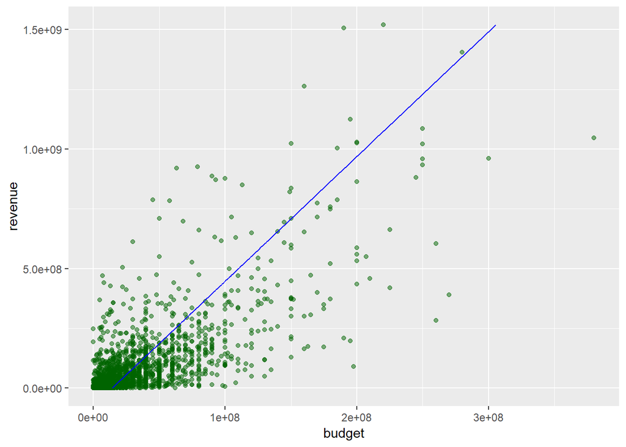

```r
nonzero.movies <- subset(data, budget > 0)

linear.model <- lm(budget ~ revenue, data = nonzero.movies)
predicted.revenue <- data.frame(predicted = predict(linear.model, nonzero.movies))

plot <- ggplot(data = nonzero.movies) +
  geom_point(aes(x = budget, y = revenue), color = "dark green", alpha = 0.5) +
  geom_line(color = "blue", data = predicted.revenue, aes(x = predicted, y = nonzero.movies$revenue))
print(plot)
```

What about language and budget?

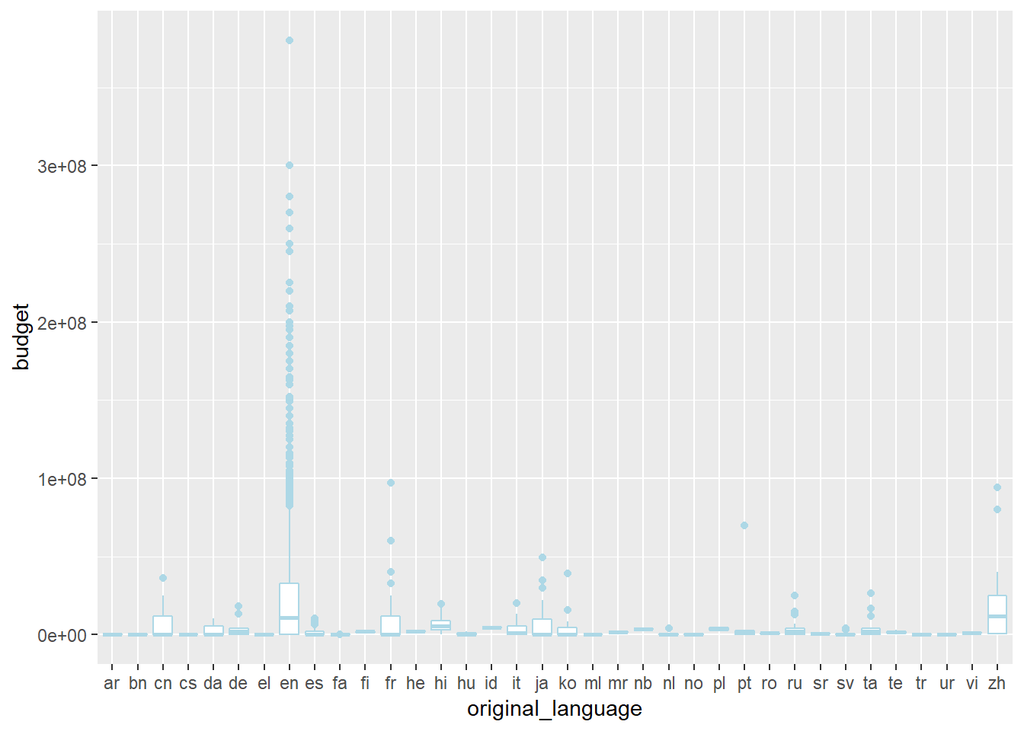

```r
plot <- ggplot(data = data, aes(x = original_language, y = budget)) +
  geom_boxplot(color = "light blue")

print(plot)
```

The only languages that make a dent in budget are English (overwhelmingly the highest budgets), then French, Chinese (both zh and cn (mainland Chinese simplified characters)) and Portuguese. Interestingly, it appears there are no mega-budget Hindi language films.

Let’s go back and redo our earlier budget and revenue graph, this time coloring the dots by film language.

```r
nonzero.movies <- subset(data, budget > 0)
nonzero.movies <- mutate(nonzero.movies, is.english = if_else(original_language == "en", "True", "False"))
print(head(nonzero.movies$is.english))
```

```
## [1] "True"  "True"  "True"  "False" "True"  "True"
```

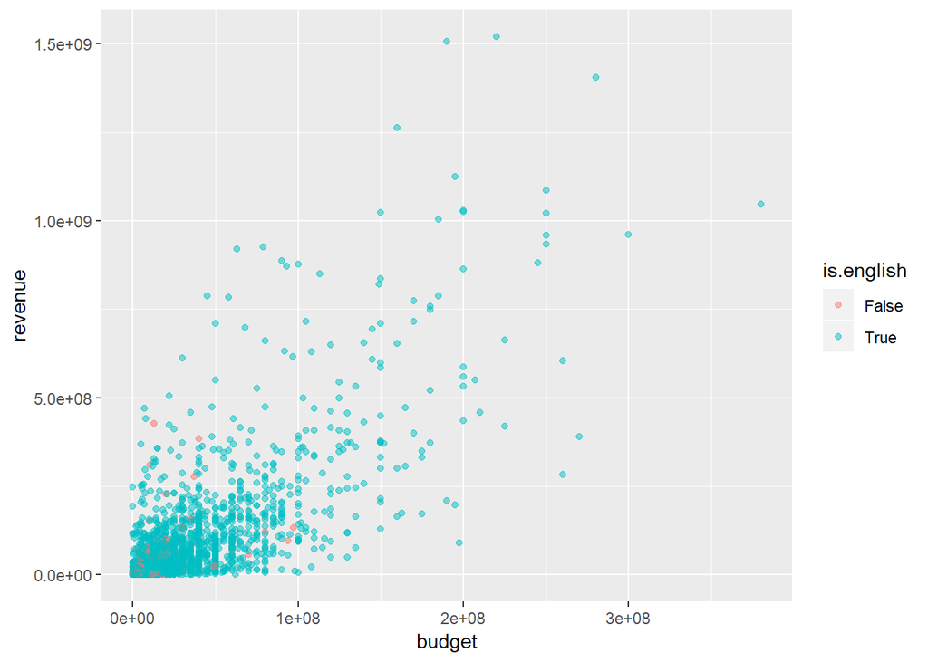

```r
plot <- ggplot(data = nonzero.movies) +
  geom_point(aes(x = budget, y = revenue, color = is.english), alpha = 0.5)
print(plot)
```

What are those non-English outliers?

```r
non.english <- subset(nonzero.movies, original_language != "en")
non.english.sorted <- top_n(non.english, 5, revenue)
print(non.english.sorted$original_title)
```

```
## [1] "Intouchables"    "दंगल" "La vita è bella" "捉妖记"
## [5] "寻龙诀"
```

Of those, I’ve (Mike speaking here) only see “La Vita” and found it amazing. Might be a good viewing list for the future.

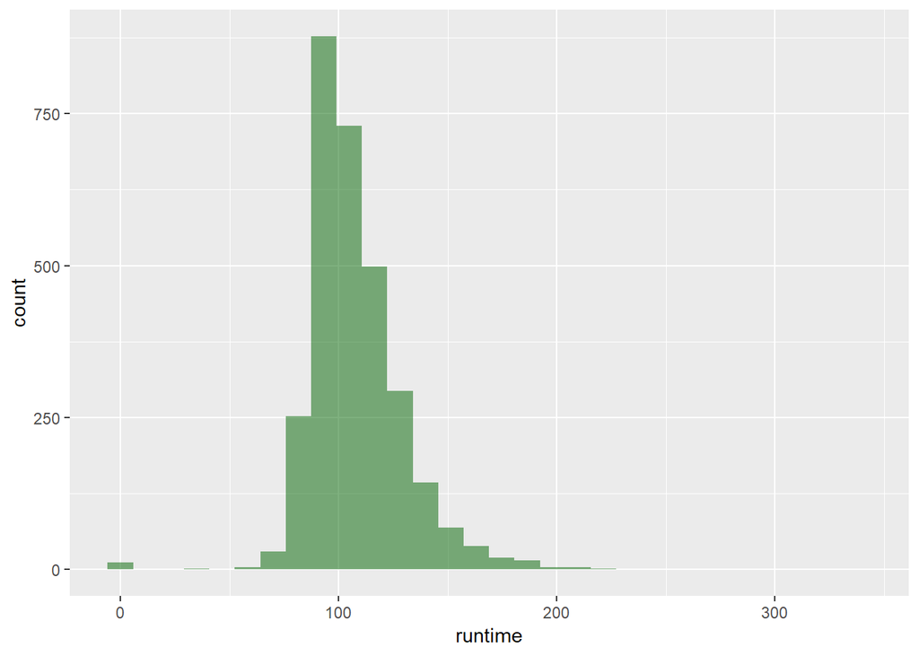

```r
ggplot(data = data)+
  geom_histogram(mapping = aes(x = runtime), fill = "dark green", alpha = 0.5)+
        geom_vline(xintercept = mean(data$runtime), color = "red", linetype = "dashed")
```

```r
## Unable to get the mean line working..
```

Most of the movies seem to run for about 100 minutes (1hr 40min) long.

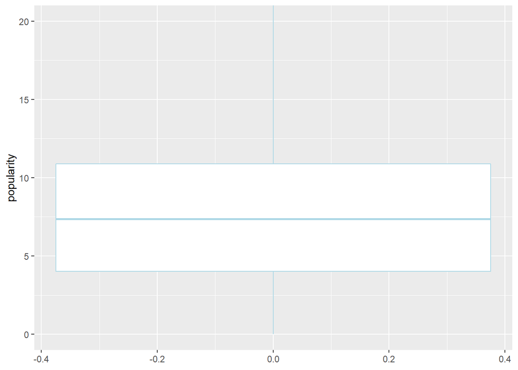

```r
ggplot(data = data) +
  geom_boxplot(aes(y = popularity), color = "light blue")+
  coord_cartesian(ylim=c(0,20))
```

```r
# summary(data$popularity)
```

From the box plot, movies in our dataset has a median rating of 7.5

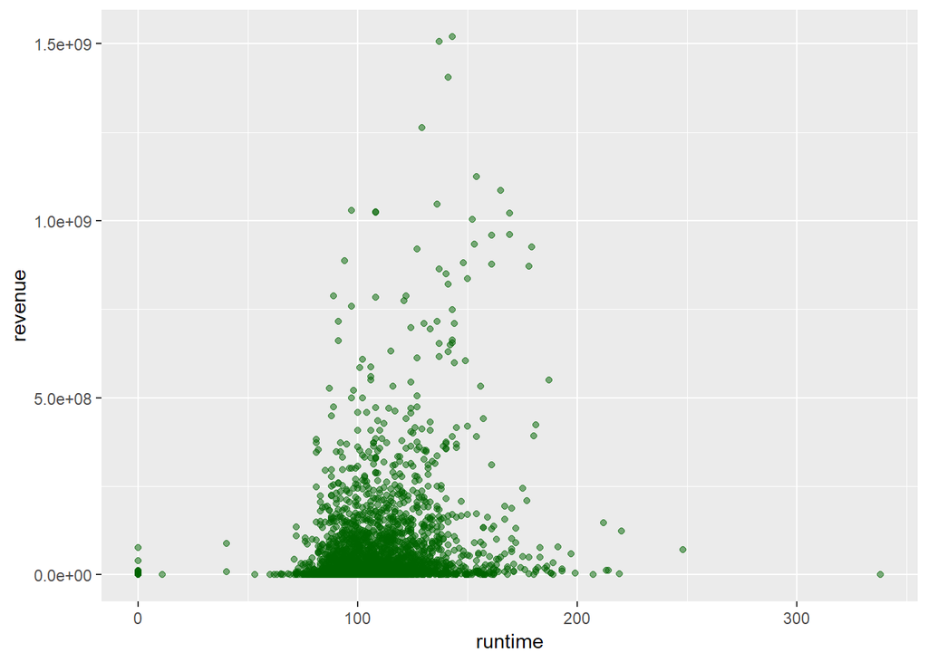

```r
ggplot(data)+
  geom_point(aes(x = runtime, y = revenue),color = "dark green", alpha = 0.5)
```

Movies that have higher revenue are not necessarily the longest movies or vice versa. The scatter plot shows no noticable relationship between the runtime of the movies and it’s revenue.

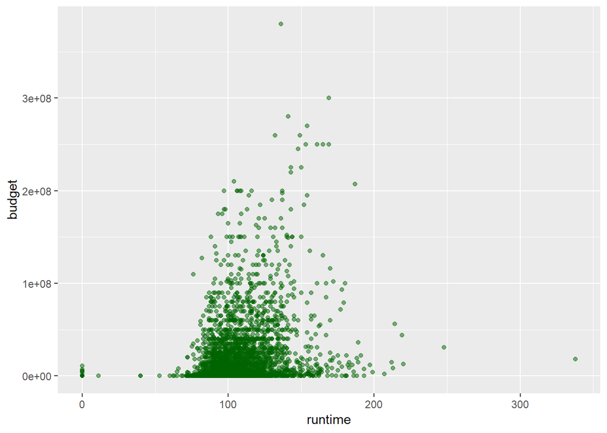

```r
ggplot(data = data)+
  geom_point(aes(x = runtime, y = budget), color = "dark green", alpha = 0.5)
```

We assumed that movies with longer runtimes might have bigger budgets. But from the scatter plot above, we can see that it is not the case. The movies that have longer runtimes doesn’t necessaritly have the bigger budget than those of shorter movies.

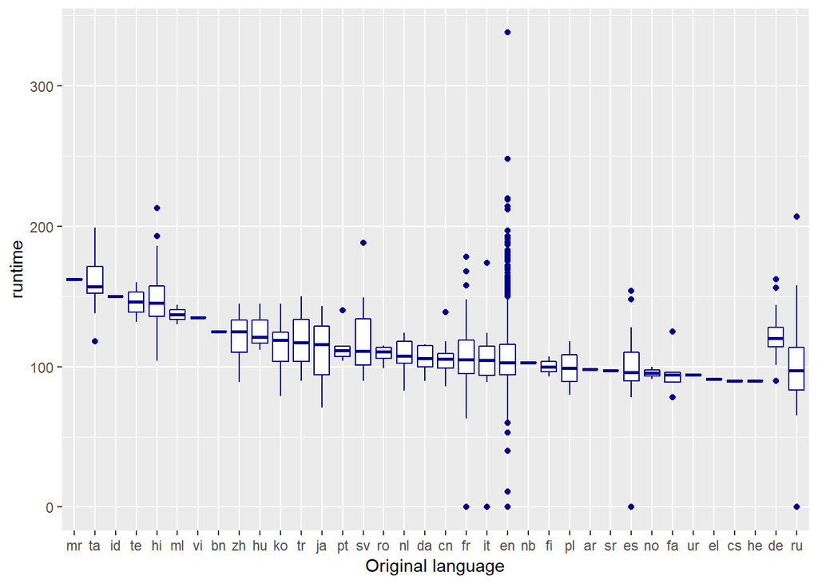

```r
ggplot(data = data, aes(x = fct_reorder(original_language, runtime, .desc = T), y = runtime)) +
  geom_boxplot(color = "dark blue")+
  labs(x = "Original language")
```

```r
  # coord_flip()
```

English movies, which has the largest budget of all the movies don’t run longer than movies with less budget. This supports our findings from the budget vs runtime scatter plot where we said there was no clear relationship betweeen movie runtime and it’s budget.

Open this link for the language codes: http://www.lingoes.net/en/translator/langcode.htm

```r
genres_df$names.factored <- as.factor(genres_df$name)
summary.genres <- genres_df %>% group_by(names.factored) %>% summarize(num1 = n())
```

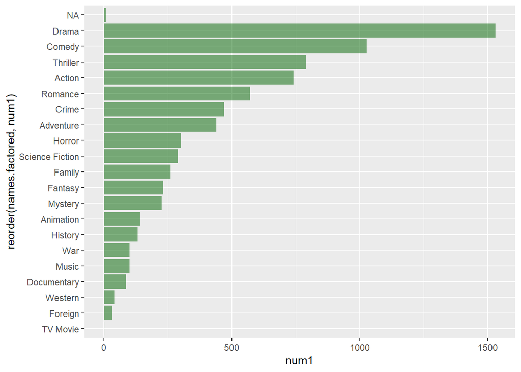

```r
ggplot(data = summary.genres) +
  geom_bar(aes(x = reorder(names.factored, num1), y = num1), fill = "dark green", alpha = 0.5, stat = "identity") +
  coord_flip()
```

```r
## Sorted now, just have to turn the columns into factors, and then reorder() them by the count of that factor.
```

Most popluar movie genres are dramas, followed by comedy, thriller and action. The drama genre has more more than tiwce the number of movies in the action genre. More than half the movies in our dataset are dramas.

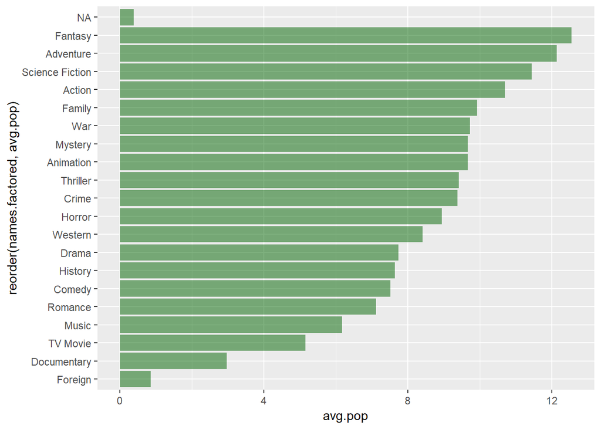

```r
## I'm trying to write a function here that can subset different genres and calculate the average rating for each genre and show it next to the bar in the graph above.

#This is a tougher one, but here's a way to make it work...

# data has the column we need called "id", but genres_df calls the same thing "movie_id" and uses the "id" column for genre id.  We need to fix that by adding a column to genre called "movie_id"

data$movie_id <- data$id

# The genres_df has movie_id as a character, which we need to make a numeric to match the original data tibble we have.

genres_df$movie_id <- as.numeric(genres_df$movie_id)

genre.and.popularity <- left_join(data, genres_df, by = "movie_id")
#print(head(genre.and.popularity))

popularity.average <- genre.and.popularity %>% group_by(names.factored) %>% summarise(avg.pop = mean(popularity))
ggplot(data = popularity.average) +
  geom_bar(aes(x = reorder(names.factored, avg.pop), y = avg.pop), fill = "dark green", alpha = 0.5, stat = "identity") +
  coord_flip()
```

```r
# check out https://www.rdocumentation.org/packages/dplyr/versions/0.7.8/topics/summarise for more on the super useful summarise() function in dplyr.
```

Fantasy, Adventure, and Science fiction are the most popular (on average), but I would assume they are also more expensive to produce.

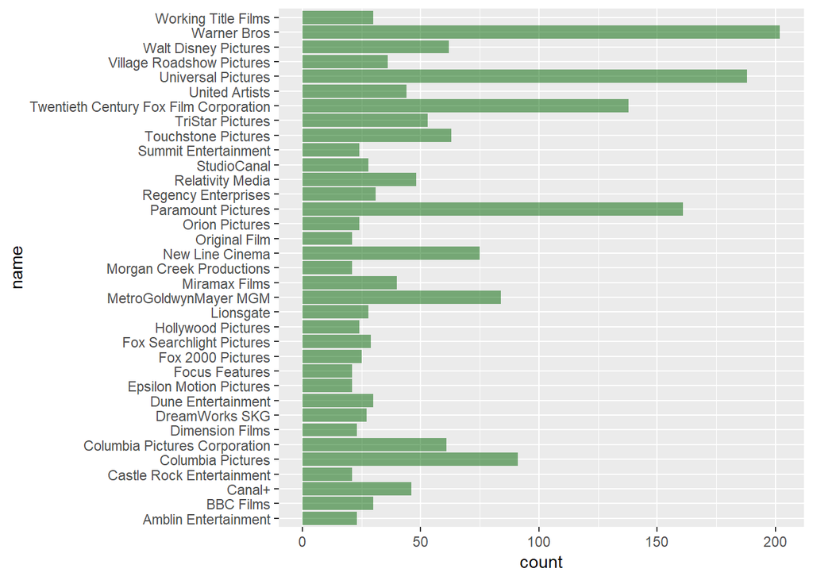

```r
total.names <- table(production_companies_df$name)

names.important <- subset(production_companies_df, name %in% names(total.names[total.names > 20]))

ggplot(data = names.important)+
  geom_bar(aes(x = name), fill = "dark green", alpha = 0.5)+
  coord_flip()
```

```r
#ggplot(data = production_companies_df)+
  #geom_bar(aes(x = name), fill = "dark green", alpha = 0.5)+
  #coord_flip()

##Unable to get a clear plot. Am I missing something? Too many and too large company names maybe? How do we visualize this column?

##As an option, as you can see I restricted the plot to companies that have more than 20 entries in the database.
```

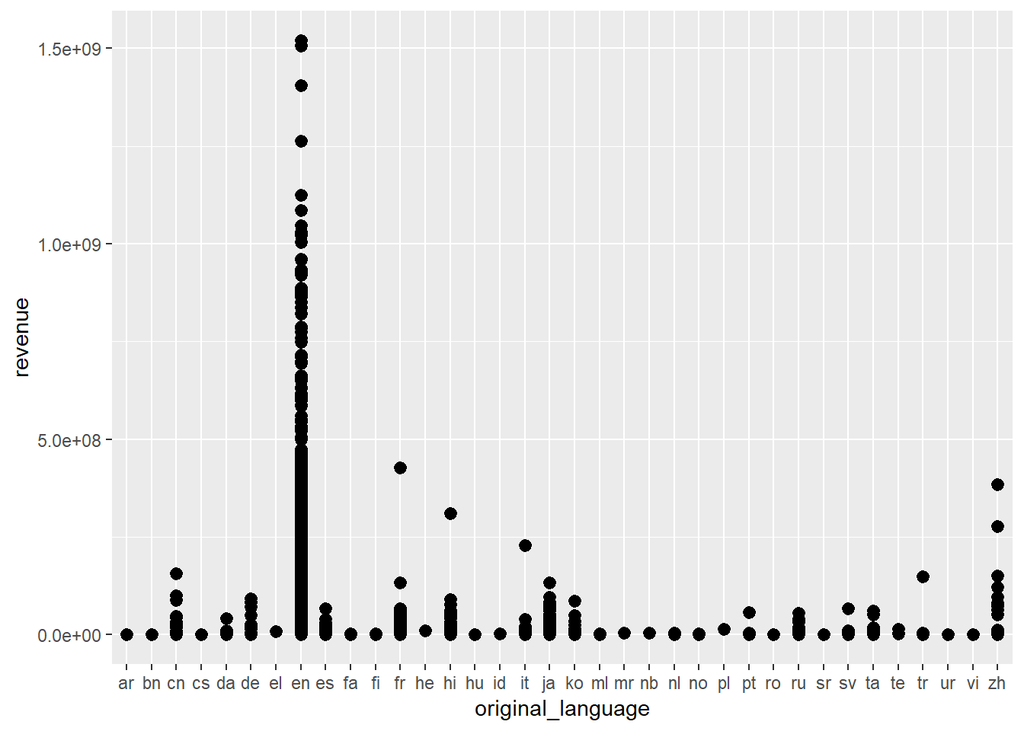

```r
ggplot(data)+
  stat_summary(aes(x = revenue, y = original_language), fun.ymin = min, fun.ymax = max,fun.y = median)+
  coord_flip()
```

English movies seem to have the higest revenue. As we saw earlier, they also have the highest budget from the budget vs origianl laguage boxplot. Chinese, French, Japanese and Hindi movies have similar revenues but nowhere near the english movies.

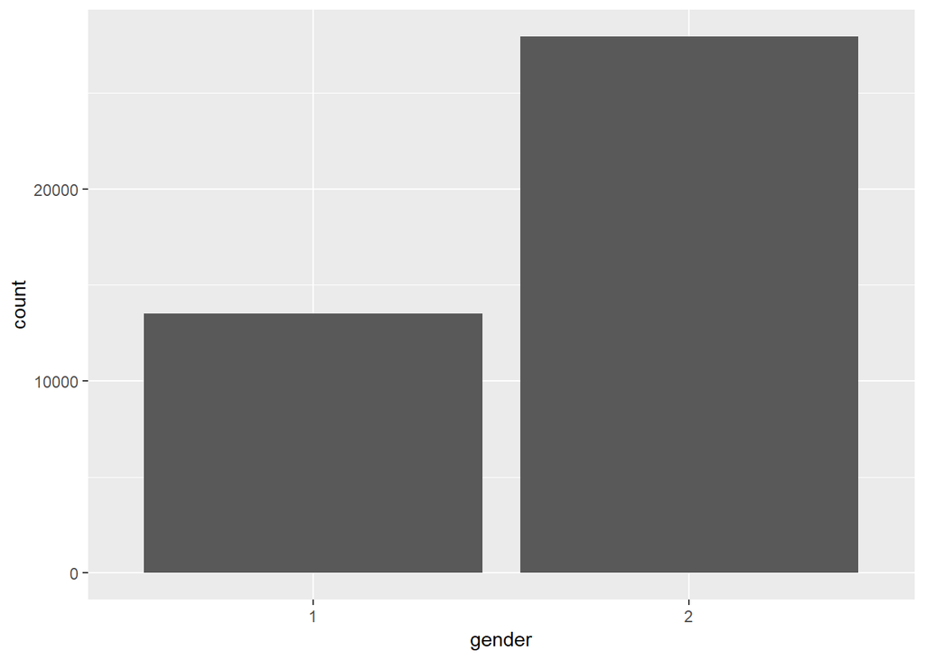

```r
gender.count <- select(cast_df, one_of(c("gender")))
gender.count <- filter(gender.count, gender == 1 | gender == 2)

ggplot(gender.count, aes(x =gender, ..count..)) +
  geom_bar()
```

```r
## Unable to print plot properly. Don't know what's going wrong..!
#names(data)

## This one took me a while to figure out, it's a data cleaning problem. Many of the genders are 1 for female, 2 for male, and 0 for unknown or unimportant (I suppose), but in other rows it's a person's name. When it is factored, all of those names end up as factors. By selecting only the correct rows, we get what I think you were looking for.
```

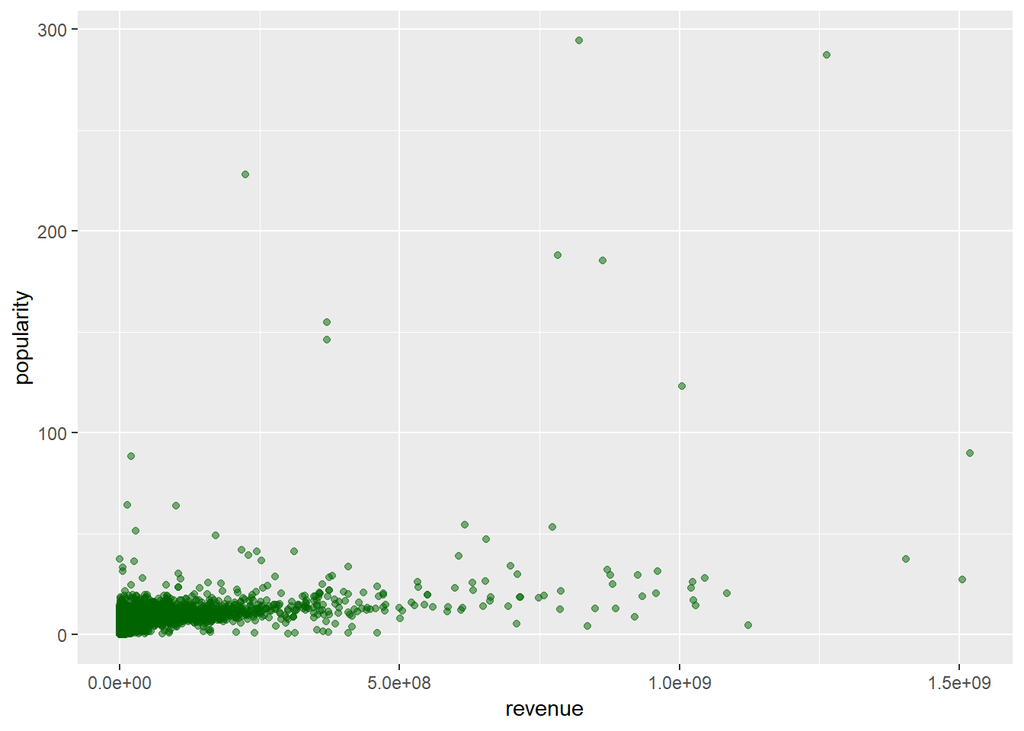

```r
ggplot(data)+
  geom_point(aes(x = revenue, y = popularity), color = "dark green", alpha = 0.5)
```

One would assume that a popoular movie would bring in more revuenue. This seems to be not the case. From the popularity vs revenue scatter plot above, a popular movie doesn’t necessarily bring in more revenue. It can also be said that a movie that has good amount of boxoffice collections might not be popular. Let’s look at the correlation between movie popularity and it’s revenue.

```r
cor(data$revenue, data$popularity)
```

```
## [1] 0.4614603
```

The correlation value of 0.46 suppors our findings from the popularity vs revenue scatter plot. It shows a weak relationship between the two variables. We can assume that some movies are popular but make less money because their target country has less money to spend and tickets are cheaper, but it’s also possible that people liked the movie after it left the box office and so the movie made less money.

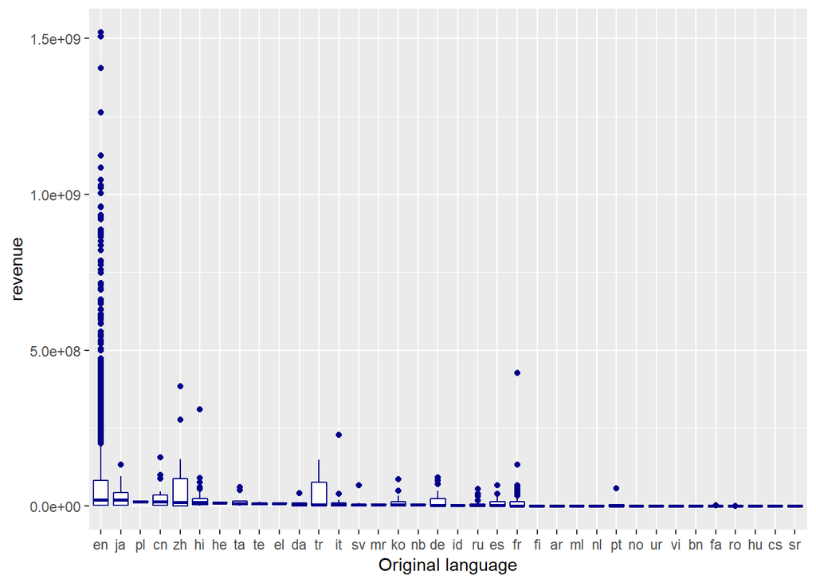

```r
ggplot(data)+
  geom_boxplot(aes(x = fct_reorder(original_language, revenue, .desc = T), y = revenue), color = "dark blue")+
  xlab("Original language")
```

Unsuprisingly, english movies has the highest revenue among all the languages. English movies overwhelmengly had the highest budget and highest revenue.Japanese movies which has the second highest revenue is among the movies with high budget. This box plot combined with the budget vs original language boxplot actually shows the relationship depected by the budget vs revenue scatter plot. There is a clear relationship between the budget and the revenue. Let’s look at the correlation.

```r
cor(data$budget, data$revenue)
```

```
## [1] 0.7529645
```

Correlation of 0.75 is fairly high and a good indicator of relationship between revenue and budget.

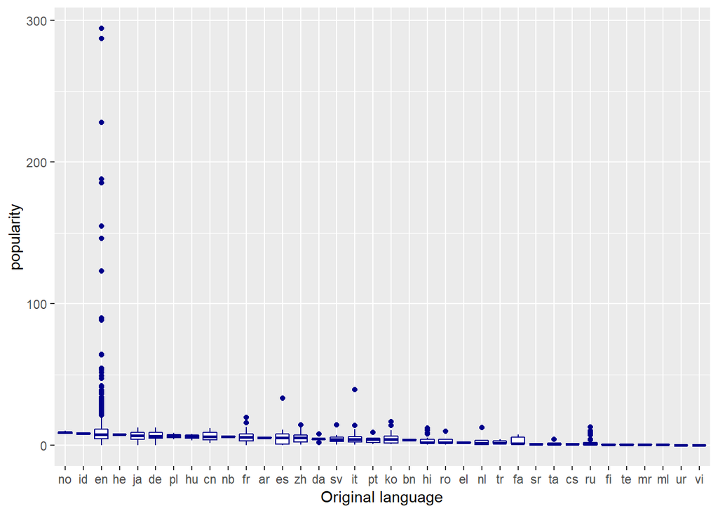

```r
ggplot(data)+
  geom_boxplot(aes(x = fct_reorder(original_language, popularity, .desc = T), y = popularity), color = "dark blue")+
  xlab("Original language")
```

To our suprise, Norwegian language seems to be the most popular followed by Indonesian and then english. Hebrew comes in at fourth and japanese at fifth. Indian movies, tough they are lengthy, are not liked by everyone. Perhaps the Norweigians and Indonesians make so few movies, that everything they make is popular in that country?

```r
table(data$original_language)
```

```
##
##   ar   bn   cn   cs   da   de   el   en   es   fa   fi   fr   he   hi   hu
##    1    1   20    1    5   18    1 2575   43    5    2   78    1   42    3
##   id   it   ja   ko   ml   mr   nb   nl   no   pl   pt   ro   ru   sr   sv
##    1   24   37   20    2    1    1    6    2    2    6    4   47    1    8
##   ta   te   tr   ur   vi   zh
##   16    2    3    1    1   19
```

This suggests our hypothesis above may be correct, only two Nowegian movies, and one Indonesian movies. People in those countries got so excited about those three movies, their popularity is high.

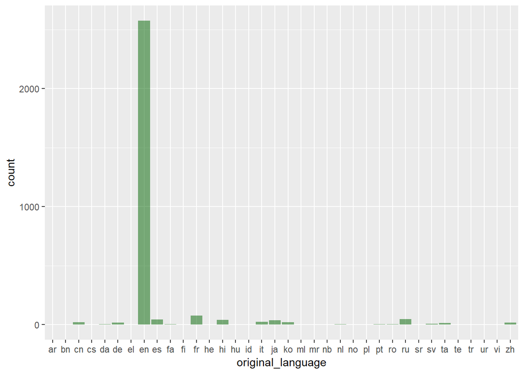

```r
ggplot(data)+
  geom_bar(aes(original_language), fill = "dark green", alpha = 0.5)
```

## 3. Feature Engineering

### A. Making a profit column

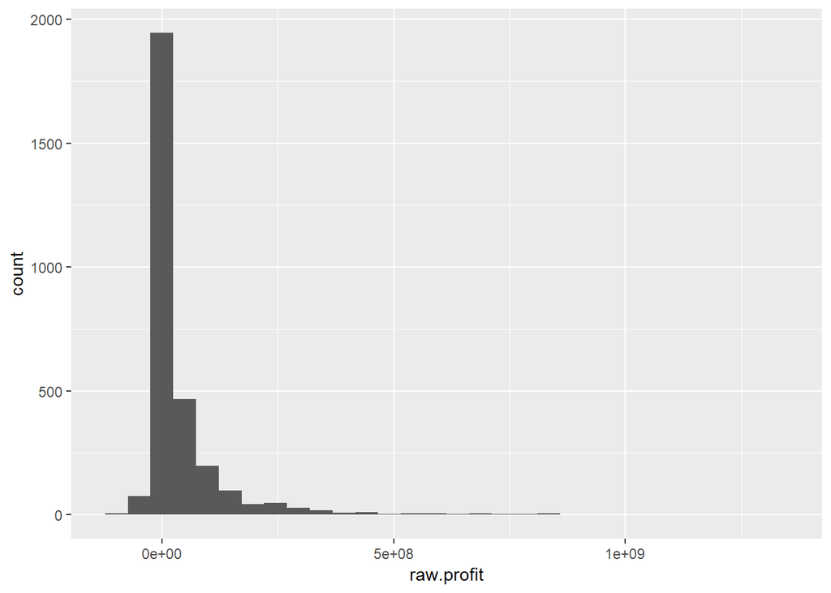

```r
data <- mutate(data, raw.profit = revenue - budget)

plot <- ggplot(data, aes(raw.profit)) + geom_histogram()
print(plot)
```

It would appear most movies make a little, some lose money, and very few make huge profits.

Let’s see profit as a function of percentage return.

```r
data <- mutate(data, percent.profit = revenue / budget)
# we have to leave out rows with missing/obviously wrong data
useful.rows <- data[data$budget > 10000, ]

#plot <- ggplot(data, aes(percent.profit)) +
#  geom_histogram(binwidth = 100, aes(y = ..density..))
#print(plot)

#how many movies were profitable?
print(count(useful.rows[useful.rows$percent.profit > 0, ]))
```

```
## # A tibble: 1 x 1
##       n
##   <int>
## 1  2165
```

```r
#2165

#how many movies made double their money?
print(count(useful.rows[useful.rows$percent.profit > 2, ]))
```

```
## # A tibble: 1 x 1
##       n
##   <int>
## 1  1081
```

```r
#1081
```

What was the most profitable?

```r
print(max(useful.rows$percent.profit))
```

```
## [1] 12890.39
```

```r
print(useful.rows$original_title[useful.rows$percent.profit > 12000])
```

```
## [1] "Paranormal Activity"
```

Paranormal Activity is the most profitable movie in our database, which is confirmed by the wikipedia article on this film. (https://en.wikipedia.org/wiki/Paranormal_Activity)